# Speakers of diverse languages structure their utterances for efficient communication

Josef Klafka

1  
jklafka@andrew.cmu.edu

Daniel Yurovsky

1,2

Abstract

What role does communicative efficiency play in how we organize our utterances? In this paper, we present a novel method of examining how much information speakers in a given language communicate in each word, surveying numerous diverse languages. We find that speakers produce frequent and informative words at regular parts of their utterances, depending on language they use. The information distribution for each language is derived in part from the features and genealogy of the language. This robust information distribution characterizes both spoken and written communication, and emerges in children’s earliest utterances. However, in real-time communication, in-context word predictability allows listeners to process information at a constant, optimal rate, regardless of the information distribution in the language they understand.

# 1 Introduction

One of the defining features of human language is its power to transmit information. We use language for a variety of different tasks: greeting friends, taking notes, signaling group identities. But all share a common unifying purpose: changing the mental state of the listener or reader of our communications (Austin 1975). Language can thus naturally thought of as a code that allows speakers to turn their intended meanings into a message that can be transmitted through the air (or paper, or electrons) and subsequently converted by listeners back into an approximation of the intended meaning (Shannon 1948).

Beyond its utility as a metaphor, this coding perspective on language is powerful because it allows a framework for rational analysis: If language has evolved to be an optimal code for information transmission, how should this code be structured (Anderson and Milson 1989)? The optimal code would have to work with two competing pressures: (1) a pressure for listeners to easily and successfully decode messages sent by the speaker, and (2) a pressure for speakers to easily code their messages and transmit them with minimal effort and error. A fundamental constriaint on both of these processes is the linear order of spoken language: sounds are produced one at a time and each is unavailable perceptually once it is no longer being produced.

The strategic solution people employ is *incremental processing*. Listeners process speech continuously as it arrives, predicting upcoming words and building expectations about the likely meaning of utterances in real-time rather than at their conclusion (Kutas and Federmeier 2011; Tanenhaus et al. 1995; Pickering and Garrod 2013). Because prediction errors can lead to severe processing costs and difficulty integrating new information, speakers should seek to minimize prediction errors. However, the cost of producing more predictable utterances is using more words. Thus, an optimal coding strategy is for speakers seeking to minimize their production costs is to produce utterances that are are just at the prediction capacity of listeners without exceeding this capacity (Aylett and Turk 2004; Genzel and Charniak 2002).

Using information theory–a mathematical framework for formalizing predictability–researchers have tested and confirmed this general prediction of optimal coding across several levels and contexts of language production. For instance, Genzel and Charniak (2002) provided a clever indirect test of this hypothesis across sentences. They showed that the predictability of successive sentences in a discourse–analyzed in isolation–decreases, as would be expected if readers use prior sentences to predict the content of future sentences and total predictability remains constant.

This prediction of optimal coding–that speakers should maintain a constant rate of predictability has been tested and confirmed in a variety of ways across levels of language. At the level of individual words, Mahowald et al. (2013) showed that speakers use shorter words in more predictive contexts and prefer the shorter versions of words in more predictive contexts, maximizing the amount of information in each word while minimizing the time spent on those words. Over time, Piantadosi, Tily, and Gibson (2011) showed that shorter words across languages tend to be more easily predictable in context and thus less informative, over and above frequency.

Efficient encoding also impacts how speakers structure phrases. The inclusion of complementizers in relative clauses (Jaeger and Levy 2007) and the use of contractions (Frank and Jaeger 2008) are two situations in sentence formation in which speakers use structure to communicate efficiently, spreading more information across a larger amount of linguistic material.

Larger parts of language, as well as languages themselves, evolve according to efficient encoding. Semantic categories of words across languages can evolve to be structured efficiently, maintaining a trade-off between informativeness and complexity in the semantic category, such as kinship terms (Kemp and Regier 2012). Languages more generally evolve according to principles of efficient communication: features of the world that are relevant to speakers become part of a language, while irrelevant features are disregarded (Perfors and Navarro 2014) and structure in langauge evolves from a trade-off between efficient and learnable encoding on the one hand and an expressive and descriptive lexicon on the other (Kirby et al. 2015).

However, despite this literature using the predictive coding model of language, one level has not yet been studied in depth: how speakers structure individual utterances. This level may show the strongest effects of variation between languages, as specific languages have properties that constrain how speakers may form utterances in those languages, such as canonical word order. These properties vary widely from language to language.

Yu et al. (2016) studied the utterance level in written English sentences using a contextless entropy model based on word frequency. They found a distinctive three-step distribution regardless of sentence length, with little information in the first words of sentences and the most information in the final words. This was surprising, as the distribution they found was robustly different from the linearly increasing trend in sentences from Genzel and Charniak (2002), and also did not resemble the uniform distribution of information that one might expect from a communicative efficiency account, in which each word has approximately equal information close to the channel capacity.

In this paper, we expand on this body of prior work in a number of novel ways. We replicate the results from Yu et al. (2016) with a metric tied to incremental word processing. We find their same distribution of information based on word frequency in English speech, as well as in English parent-child conversations. We extend our metric to include context, and show that the addition of context for each word smoothes out language-specific distributions. We expand the study of information density to the largest set of languages considered so far, and incorporate contextual and typological information into our analysis. Speakers will tend to distribute information in a language constrained but not determined by the morphology, syntax and phonology of that language. As soon as a child starts speaking, they tend to distribute information in their utterances according to the characteristic distribution in their language.

# 2 Methods

Shannon (1948) defined information as “the reduction in uncertainty about one variable given that the value of another variable is known”. We use a metric proposed for the study of information transmission more generally by Shannon and applied to words specifically by Levy (2008): lexical surprisal. This measure defines the information in word based on the ratio of possible continuations of the sentence after to before the word is seen. Equivalently, we can compute surprisal with the predictability of the word, as in the formula below. The surprisal of a word is inversely proportional to the predictability of a word, such that less common and less predictable words carry more information.

$$\text{surprisal}(\text{word}) = -\log P(\text{word})$$

The surprisal of a word is also correlated with the processing cost of a word, with evidence from eye-tracking (Smith and Levy 2013) and ERP (Frank et al. 2015) studies, among other sources. Considered without context, the surprisal of an individual word is inversely proportional to the frequency of that word, so that the less often a person has seen a word, the more information that word holds. For example, “flower” has less information than “azalea” because “flower” is much more common than “azalea”. Though the two words have the same length in number of letters, it’s more difficult to process “azalea” when reading it here than when reading “flower”. Frequency is intimately tied information content in words, with much of the differences between words frequencies being explained by information content cross-linguistically (Piantadosi, Tily, and Gibson 2011).

However, when reading or listening, people don’t just consider each word as an isolated linguistic signal. Instead, listeners use the words they have already heard to predict and decode the current word. Following this incremental processing paradigm, we can also condition the surprisal of a word in its context. In the formula below, widenotes the word currently being read or heard, while $w_{i-1}$ denotes the first word before the current word, $w_{i-2}$ denotes the second word before the current word, and so on.

$$\text{surprisal}(w_i|w_{i-1}w_{i-2}...) = -log P(w_i|w_{i-1}w_{i-2}...)$$
$$= -log \frac{P(w_i,w_{i-1}w_{i-2},...)}{P(w_{i-1}w_{i-2}...)}$$

When we use a word or two of context in our surprisal calculations, then the set of reasonable final items in our ngrams is greatly restricted. “Flower” may contain less information than “azalea” when we consider the words independently of their context, but with context this can be reversed. Flower appears in a variety of contexts, and so the information content of a word like “flower” in a particular context may be higher than “azalea”. If you only have azaleas in your garden, then hearing someone say “in that garden, look at the flowers” may be higher surprisal for you: you expect them to say “azalea”. This prediction does not need many words before to work out, for example in “I take my coffee with cream and sugar”. When you hear “cream and”, you automatically predict “sugar” or maybe “honey”, but there are few possible continuations with even those two words. Hearing “I” restricts the next word to a verb, or possibly an adverb, and since you have just heard the speaker refer to themselves in the first person singular, your set of possible completions is significantly restricted.

Ideally, we would like to predict each word using all of the information available. For example, in an utterance of twenty words, we would be able to use the previous $19$ words of context to predict the twentieth word. However, we would need to train on a corpus of many trillion word tokens to predict with this amount of context, and we want to directly compare how predictable each word is regardless of its position in an utterance. Therefore, we use a *Markov assumption*: we condition our language model’s next predictions on a small window of context instead of all preceding words. We train ngram language models inedpendently on each corpus.

$$\text{surprisal}(w_i|w_{i-1}w_{i-2}...) \approx \text{surprisal}(w_i|w_{i-1}w_{i-2})$$

For our frequency-based model, we don’t incorporate context and so each ngram has an order of $1$: unigrams. To incorporate context into our models, we train bigram and trigram language models, which incorporate one and two words of context for each processed word, respectively. Although these models may seem to use an inconsequential amount of context when predicting the next word, bigram and trigram models introduce a great deal of improvement over unigram models across tasks (Chen and Goodman 1999). Models with order greater than $3$ have issues with overfitting to the corpus and only predicting observed sequences, often generalizing poorly.

In our contextual models, we face another issue of overfitting: we only train our model on those utterances which occur in the corpus and test our model on the same utterances. This ignores possible other utterances which the speakers could have produced, e.g. the words “I”, “saw” and “bears” are in the corpus vocabulary, which the speaker may not have produced in the corpus but could have produced. To combat this issue, we use modified Kneser-Ney smoothing as implemented in the KenLM toolkit (Heafield et al. 2013). Briefly, this smoothing technique discounts all ngram counts, which reduces the impact of rare ngrams on probability calculations, and interpolates lower-order ngrams into the calcuations. These lower-order ngrams are weighted according to the number of distinct contexts they occur as a continuation (e.g. “Francisco” may be a common word in a corpus, but likely only occurs after “San” as in “San Francisco”, so it receives a lower weighting). For a more complete explanation of modified Kneser-Ney smoothing, see Chen and Goodman (1999).

Once we have fitted our language model, we can compute the surprisal of a continuation by simply taking the negative log-probability of that word’s ngram probability. To find the average information for a given position in a corpus, we take all utterances of a given length, and for each word position in utterances of that length, we compute the average of the surprisals for all of the non-unique words that occur in that position, conditioned or not conditioned on context. By computing these averages for each word position in an utterance, we compute a low-dimensional approximation to the average distribution of information in the corpus. With the surprisal metric, we base the information contained in each word on how often the word is encountered in its context in the corpus. As long as the corpus is representative of the language or population we study, then the distribution of information is approximated for that language or population as a whole.

The flexibility of the surprisal metric we employ in this paper allows us to calculate the anticipated information for an individual utterance, as most work with the metric has done in the past. Averaging together the surprisal values for a word position within utterances is actually a step further than prior work, and indicates the tendencies speakers gravitate towards instead of examining individual stimuli in psycholinguistic experiments.

The frequency-based surprisal metric gives us an idea of when in their utterances speakers say frequent i.e. independently information-rich words. The context-based surprisal metric show us how speakers tend to distribute the information in utterances relative to real-time processing in communication. We expect a priori that our frequency-based surprisal curve will be flat. No one part of the sentence will on average have words that are more frequent than another across utterance lengths. Similarly, we expect that there will be a small smoothing effect for our contextual surprisal metric.

# 3 Written and Spoken English have the same information distribution

We first turn to working with written English in the British National Corpus (BNC; Leech 1992). The BNC is a collection of spoken and written records (90% written) from the turn of the century, intended to be a representative sample of British English. Using their word entropy metric without context, Yu et al. found a distinctive three-step distribution for information in written English sentences in the corpus. The first word tended to contain little information. While the middle words of sentences each had more information than the first word, they found a flat and non-increasing rate of information transmission across the middle of sentences. The final word contained the most, though not most, of the information out of any in the sentence, with a noticeable spike in information. They found the same distribution across sentence lengths, from sentences with $15$ words to sentences with $45$ words.

We replicate the Yu et al. (2016) result using the surprisal metric in place of the entropy metric. We use the frequency-based or “contextless” surprisal metric, which determines the average distribution of information based on word frequencies in a corpus. A priori we expect that the frequency-based metric will produce a flat distribution of information across word positions in the BNC.

We find the same frequency-based information trajectory as Yu et al. with little information in the first words of utterances and the most information in the final word, see (fig:bnc_unigrams).

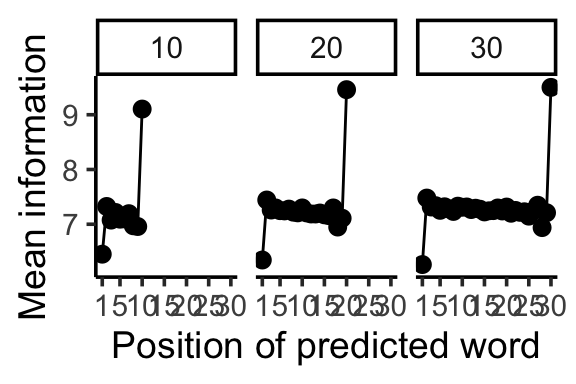

(#fig:bnc_unigrams)BNC frequency-based information curves

We have found a unique average distribution of information that appears to characterize the English language as a whole, utterance length. This distribution indicates that in English, the words we speak or write at the beginnings of utterances have little information, while the words we speak or write at the ends of utterances have a lot of information. The words in the middle of utterances have a middling amount of information, without the increasing trend in information from word to word that we might expect from (Genzel and Charniak 2002).

What about context? So far we’ve only discussed the frequency-based metric, considering words on their own without any explicit incorporation of prior context. As previously discussed, listeners decode information and process what they hear incrementally, using prior heard words to ease the comprehension process. We now include one word of context (bigrams) and then two words of context (trigrams) for each word in our measurements. We observe a flattening effect of context across both modalities and all speaker populations. After the first word or two, where the listener does not have access to prior context, then they decode information at a flat and more or less uniform rate. The contextual information curves for the BNC are in Figure (fig:bnc_trigrams).

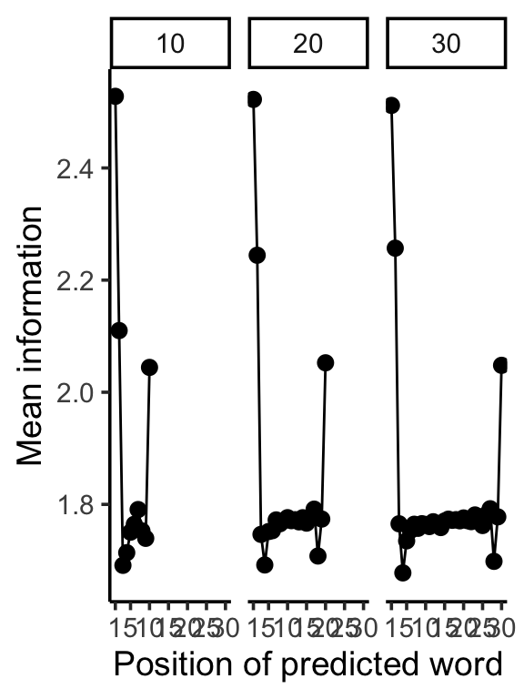

(#fig:bnc_trigrams)British National Corpus trigram context-based information curves

Speakers produce information at a more or less constant rate, avoiding peaks or troughs in their information distribution, except at the beginnings of utterances, where listeners may not have any context to predict what the speaker is going to say. Speakers of English tend towards a characteristic and uneven distribution of word information based on frequencies within their utterances. Their interlocutors, however, once they have a word or two of context, decode information at a more or less constant and optimal rate.

# 4 English CDS and child speech

We found that English speakers and writers used the same robust and distinctive distribution of information within each utterance, regardless of the number of words in their utterances. To determine if this distribution truly characterizes all speakers of the English language as a whole, we wanted to examine speech from English-speaking children who are producing their very first multi-word utterances. We hypothesize the three-step distribution of information we found for English will characterize child speech and child-directed speech.

We observe the same distinctive distribution of information for parents and children in the child speech corpus as we did for adults in the BNC. The distribution of information we found at the level of individual words in English, therefore, characterizes the English language as a whole and not only adult utterances, not only written utterances. See (fig:providence_unigrams).

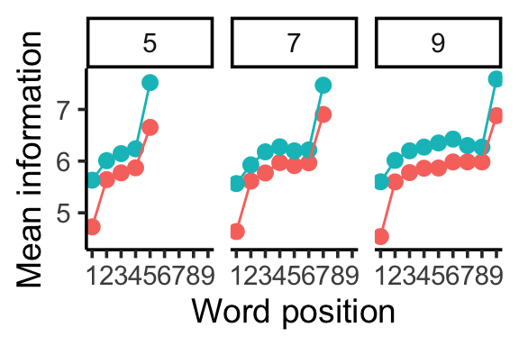

(#fig:providence_unigrams)North American English frequency-based information curves. Lines around each point indicate 95% confidence intervals computed with non-parametric bootstrap

What about predictive processing in the child-directed speech and child speech? When incorporating one or two words of predictive context, we observe the same trend as in the BNC. Beyond the first couple of words, once your interlocutor has enough context to predict with some accuracy what you will say next, then you decode information from their speech stream at a constant and optimal rate. This applies to parents and children speaking to one another, as well as adults speaking and writing to one another. See (fig:english_trigrams).

[figure not shown]

(#fig:english_trigrams)Providence trigram context-based information curves

# 5 Child speech and CDS across languages

So far, we have only looked at the distribution of information in words in English, both with and without context. We have examined child speech, child-directed speech and adult-directed speech, as well as writing samples selected to be representative of British English as a whole. But this only captures the picture for English.

We now turn to a small number of typologically diverse languages, and conduct the same analysis, using a monolingual adult-child speech corpora from CHILDES (MacWhinney 2000) to compare the results from these languages directly to our results from the English Providence corpus. We use corpora for Spanish, German, French, Mandarin and Japanese. All of the language collections consist mainly of shorter utterances: most utterances in the corpora are under 10 words long. Mandarin and Japanese are not natively written using the Latin alphabet, and moreover words are not segmented in their native scripts. Instead of the native scripts, we use transliterations from the corpus for each of the Mandarin and Japanese utterances into pinyin for Mandarin and romanji for Japanese where words are segmented.

We observe a distinct and characteristic frequency-based information trajectory for each language, robust across each utterance length. We see the same distribution of information for both parents and children. The parent on average has more information in their utterances. This is an effect of the surprisal metric: parents speak more utterances than their children in most of the corpora, which inflates the number of tokens they use and increases the surprisal of hearing a rare word. We include the frequency-based information curve from the North American English CHILDES collection for comparison.

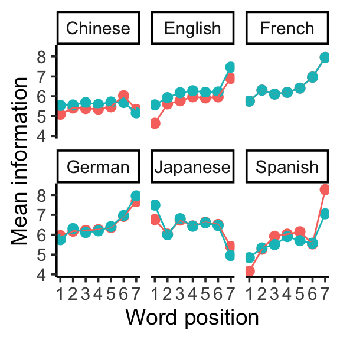

Figure 5.1: CHILDES frequency-based information curves

English, Spanish, French and German feature similar information curves shapes, with slight variations. The German information curve features lower information for longer towards the beginnings of utterances, possibly due to the grammatical restriction that the second word in German utterances must be a verb (V2). Spanish features a larger spike in the amount of information in the final words of utterances. For Japanese and Mandarin, we observe completely different frequency-based information curve trajectories. The Japanese frequency-based information curve trajectory begins high and finishes low, the mirror image of the European language information curves. The Mandarin curve begins low and finishes low, but features high information in the middle of utterances. We hypothesize this may be due to both Japanese and Mandarin speakers typically ending their utterances with particles, which contain very little information on their own. The penultimate noun with the speakers pair the particles are where the information lies.

For the bigram and trigram information curves, we see the same contextual smoothing effect as for all the corpora we worked with in English. While the frequency-based information curves may depend based on the language, the contextual information curves show the same trajectory cross-linguistically. Using more than two words of context is difficult for parent-child speech corpora because the utterances are so short on average (less than $10$ words). We hypothesize that the frequency-based information curves may vary based on the genealogy and typology of the languages in question, but this does not extend to the information curves with two words of context in particular.

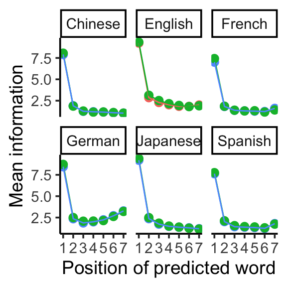

Figure 5.2: CHILDES trigram context-based information curves

# 6 Language structure and large-scale data analysis: methods

To make a claim about language as a whole and languages on a larger scale, we needed to use larger corpora and a much larger number of languages. We pulled corpora for $159$ diverse languages from Wikipedia, each of which had at least $10000$ articles on the knowledge base. We split each article up into sentences; the variance in sentence lengths for Wikipedia was significantly larger than for the CHILDES corpora we used in the previous section. Most sentences in Wikipedia contained between $10$ and $30$ words, unlike the CHILDES corpora which mainly contained utterances with under 10 words. We excluded the small fraction of utterances with more than $50$ words since they were small in number and, from manual inspection, uncharacteristic of typical written sentences.

How do we analyze more than $40$ different surprisal curves for each language, adding up to several thousand surprisal curves total? We used two different strategies, which yielded identical results upon analysis. Each strategy gave us a five-dimensional vector space embedding for each language in a Wikipedia “slope space”. For the first strategy, we split each sentence length by number of words into fifths, and computed surprisal values for the closest word position to each quintile. We then computed the slopes between the surprisal values at neighboring quintiles, yielding five slope values for each curve. For the second strategy, we split each sentence length by number of words into sections based on those areas of the surprisal curves that had seemed most important before: between the first and second word; between the second and third word; between the third word and third-to-last word; between the third-to-last word and the second to last word; and between the second-to-last word and the last word. We then similarly computed surprisal values at each of these positions, and similarly computed slopes between the surprisal values at each position, giving us another five slope values for each language summarizing the surprisal curves. Illustrations of these two strategies are in Figure (fig:treatments)

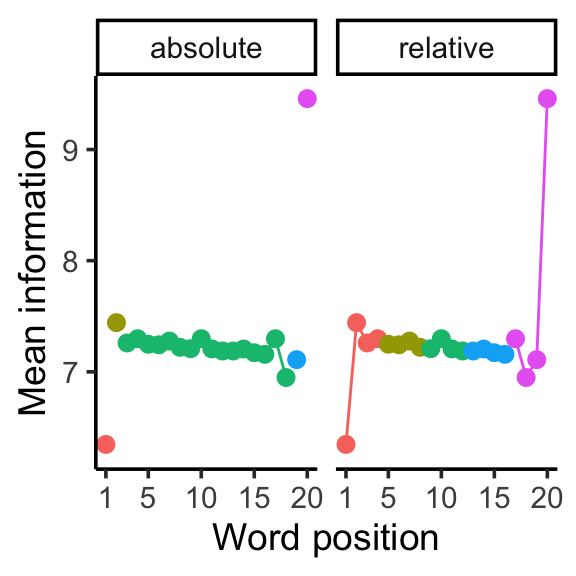

We computed unigram, bigram and trigram values for each language, and grouped the contextual and frequency-based values for each treatment.

To more rigorously described the differences between languages, we used data from the World Atlas of Language Structures (WALS; Dryer and Haspelmath 2013). WALS has data for $144$ typological features in $2569$ languages around the world. These features describe aspects of morphology, syntax, phonology, etymology and semantics–in short the features describe the structures in each language. As WALS is a compiled database from dozens of papers from different authors, most of the features and languages are fairly sparse. Even limiting ourselves to the $159$ language corpora we pulled from Wikipedia and $122$ features from WALS, there are nearly $20000$ individual possible feature values, fewer than half of which were already inputted for those languages in the WALS database.

We used the Multiple Imputation Multiple Correspondence Analysis algorithm (MIMCA; Audigier, Husson, and Josse 2017) to fill in the missing data using statistical imputation. MIMCA essentially uses mean imputation to begin with the missing values, then performs repeatedly performs principle components analysis on and reconstructs the contingency table formed from observations in categorical variables. By the end of this we had frequency-based and contextual information curves for the $159$ language corpora pulled from Wikipedia, along with $122$ typological features for each language.

However, the WALS features describe specific structural differences between languages, while our surprisal metric is lexical. To target lexical differences between languages, we computed the average normalized Levenshtein distance (LDN; Holman et al. 2008) over the $40$ item Swadesh list (Swadesh 1955), retrieved from the ASJP database (Wichmann et al. 2016). The Swadesh list is designed to include near-universal words that target basic cognitive concepts, and are useful in determining the genealogical similarities and differences between languages. The results of classifying languages using the Swadesh list and LDN are correlated with those using WALS features, but the Swadesh list and LDN do not suffer from the same sparsity problem as WALS (Holman et al. 2008).

# 7 Language structures and large-scale data analysis: results

We ran a hierarchical clustering algorithm on the unigram information curves using the hclust package from the R stats core library (Team and others 2013). We used the complete linkage algorithm for hierarchical clustering with distances between information curves in language computed using cosine distance between their embeddings in the slope space. The complete linkage algorithm at every step pairs each language or cluster of languages with its closest neighboring language or cluster. A sample from the dendrogram is shown in Figure (fig:dendro), and the full tree can be constructed using the code in our GitHub repository. The language family-like structure can be seen at first glance, although the dendrogram does not exactly replicate language genealogy for all $159$ languages. This suggests using a first-pass quantitative method that the information curves do correspond in some measure to language families, but language families do not explain the entire story.

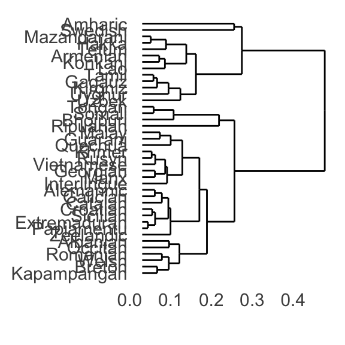

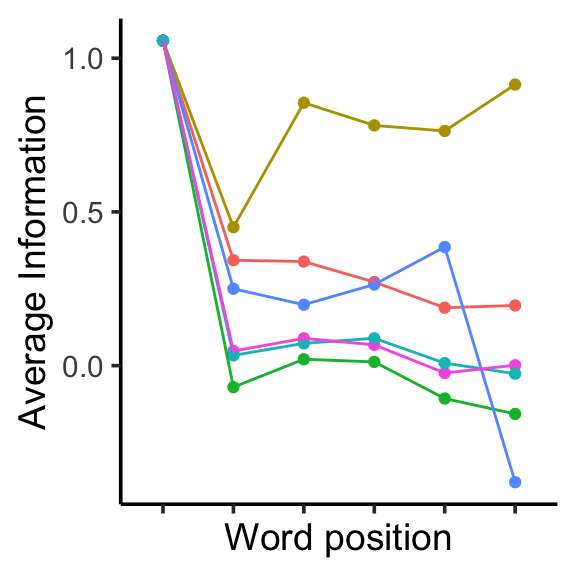

(#fig:wiki_trigrams)Some trigram information curves from the Wikipedia data

[figure not shown]

(#fig:linear_models)Some linear model results from Wikipedia and WALS features

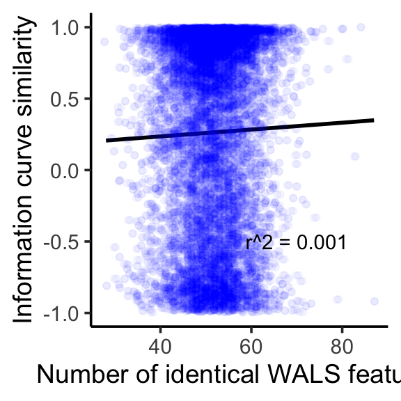

(#fig:cosine_wals)wals features vs cosine similarity

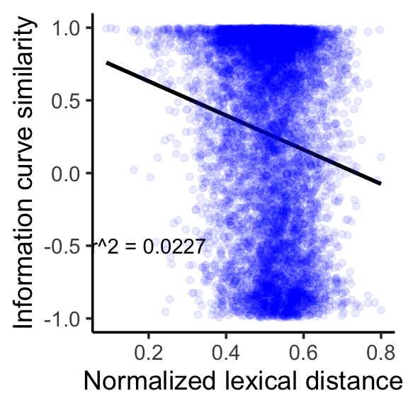

(#fig:cosine_ldn)ldn features vs cosine similarity

# 8 Discussion

By considering the distribution of information at the level of utterances and sentences, we join together the information-theoretic work focusing on sub-word units and words, and that focusing on paragraphs. In doing so, we show that frequency and context-based metrics complement one another in studying efficiency and information in language. We directly link linguistic efficiency in a language to the genealogy and properties of that language, We provide evidence for a novel linguistic universal: low processing cost for listeners beyond the first words in utterances, driven by high average word predictability in conversation. Also considering the developmental angle, observing language-specific information distributions arising as soon as children begin speaking in multi-word utterances.

Throughout this work we have averaged the surprisal values at each position. Averaging removes variation, which in turn may obscure trends in the data. As discussed in the methods section, the surprisal metric has historically been used for calculating the information and processing cost for individual utterances, and our use of the metric here is actually a step forward rather than a step back. Future work can investigate variation in how speakers distribute information in individual utterances.

The WALS database we used to investigate typological variation in the information curves is overall sparse. We imputed well over $50\%$ of the WALS features for most of our $159$ languages, although all of the languages had at least $20$ features evaluated in WALS. A large part of this is due to WALS being a collection of a number of different studies, instead of a systematic effort to catalogue variation across the world’s languages. Additionally, WALS features are meant to describe specific microvariations in languages, not to provide a comprehensive typological representation of each language compared to each other language. This may be why the Swadesh list provided a higher correlation for describing the differences in information curves: Swadesh (1955) intended the list to allow researchers to more comprehensively compared and constrast lexical differences between languages. For our Wikipedia analysis, we also reduce all of a language’s variation down to a five-dimensional vector. These information curve representations show a surprising amount of variation despite the degree of compression.

# 9 References

Anderson, John R, and Robert Milson. 1989. “Human Memory: An Adaptive Perspective.” *Psychological Review* 96 (4). American Psychological Association: 703.

Audigier, Vincent, François Husson, and Julie Josse. 2017. “MIMCA: Multiple Imputation for Categorical Variables with Multiple Correspondence Analysis.” *Statistics and Computing* 27 (2). Springer: 501–18.

Austin, John Langshaw. 1975. *How to Do Things with Words*. Oxford university press.

Aylett, Matthew, and Alice Turk. 2004. “The Smooth Signal Redundancy Hypothesis: A Functional Explanation for Relationships Between Redundancy, Prosodic Prominence, and Duration in Spontaneous Speech.” *Language and Speech* 47 (1). SAGE Publications Sage UK: London, England: 31–56.

Bates, Douglas, Martin Mächler, Ben Bolker, and Steve Walker. 2014. “Fitting Linear Mixed-Effects Models Using Lme4.” *arXiv Preprint arXiv:1406.5823*.

Chen, Stanley F, and Joshua Goodman. 1999. “An Empirical Study of Smoothing Techniques for Language Modeling.” *Computer Speech & Language* 13 (4). Elsevier: 359–94.

Dryer, Matthew S., and Martin Haspelmath, eds. 2013. *WALS Online*. Leipzig: Max Planck Institute for Evolutionary Anthropology. https://wals.info/.

Frank, Austin F, and T Florain Jaeger. 2008. “Speaking Rationally: Uniform Information Density as an Optimal Strategy for Language Production.” In *Proceedings of the Annual Meeting of the Cognitive Science Society*. Vol. 30. 30.

Frank, Stefan L, Leun J Otten, Giulia Galli, and Gabriella Vigliocco. 2015. “The Erp Response to the Amount of Information Conveyed by Words in Sentences.” *Brain and Language* 140. Elsevier: 1–11.

Genzel, Dmitriy, and Eugene Charniak. 2002. “Entropy Rate Constancy in Text.” In *Proceedings of the 40th Annual Meeting of the Association for Computational Linguistics*, 199–206.

Heafield, Kenneth, Ivan Pouzyrevsky, Jonathan H Clark, and Philipp Koehn. 2013. “Scalable Modified Kneser-Ney Language Model Estimation.” In *Proceedings of the 51st Annual Meeting of the Association for Computational Linguistics (Volume 2: Short Papers)*, 690–96.

Holman, Eric W, Søren Wichmann, Cecil H Brown, Viveka Velupillai, André Müller, Dik Bakker, and others. 2008. “Advances in Automated Language Classification.” *Quantitative Investigations in Theoretical Linguistics*, 40–43.

Jaeger, T Florian, and Roger P Levy. 2007. “Speakers Optimize Information Density Through Syntactic Reduction.” In *Advances in Neural Information Processing Systems*, 849–56.

Kemp, Charles, and Terry Regier. 2012. “Kinship Categories Across Languages Reflect General Communicative Principles.” *Science* 336 (6084). American Association for the Advancement of Science: 1049–54.

Kirby, Simon, Monica Tamariz, Hannah Cornish, and Kenny Smith. 2015. “Compression and Communication in the Cultural Evolution of Linguistic Structure.” *Cognition* 141. Elsevier: 87–102.

Kutas, Marta, and Kara D Federmeier. 2011. “Thirty Years and Counting: Finding Meaning in the N400 Component of the Event-Related Brain Potential (Erp).” *Annual Review of Psychology* 62. Annual Reviews: 621–47.

Leech, Geoffrey Neil. 1992. “100 Million Words of English: The British National Corpus (Bnc).” 서울대학교 언어교육원.

Levy, Roger. 2008. “Expectation-Based Syntactic Comprehension.” *Cognition* 106 (3). Elsevier: 1126–77.

MacWhinney, Brian. 2000. *The Childes Project: The Database*. Vol. 2. Psychology Press.

Mahowald, Kyle, Evelina Fedorenko, Steven T Piantadosi, and Edward Gibson. 2013. “Info/Information Theory: Speakers Choose Shorter Words in Predictive Contexts.” *Cognition* 126 (2). Elsevier: 313–18.

Perfors, Amy, and Daniel J Navarro. 2014. “Language Evolution Can Be Shaped by the Structure of the World.” *Cognitive Science* 38 (4). Wiley Online Library: 775–93.

Piantadosi, Steven T, Harry Tily, and Edward Gibson. 2011. “Word Lengths Are Optimized for Efficient Communication.” *Proceedings of the National Academy of Sciences* 108 (9). National Acad Sciences: 3526–9.

Pickering, Martin J, and Simon Garrod. 2013. “An Integrated Theory of Language Production and Comprehension.” *Behavioral and Brain Sciences* 36 (4). Cambridge University Press: 329–47.

Sanchez, Alessandro, Stephan C Meylan, Mika Braginsky, Kyle E MacDonald, Daniel Yurovsky, and Michael C Frank. 2019. “Childes-Db: A Flexible and Reproducible Interface to the Child Language Data Exchange System.” *Behavior Research Methods* 51 (4). Springer: 1928–41.

Shannon, Claude Elwood. 1948. “A Mathematical Theory of Communication.” *Bell System Technical Journal* 27 (3). Wiley Online Library: 379–423.

Smith, Nathaniel J, and Roger Levy. 2013. “The Effect of Word Predictability on Reading Time Is Logarithmic.” *Cognition* 128 (3). Elsevier: 302–19.

Swadesh, Morris. 1955. “Towards Greater Accuracy in Lexicostatistic Dating.” *International Journal of American Linguistics* 21 (2). Indiana University: 121–37.

Tanenhaus, Michael K, Michael J Spivey-Knowlton, Kathleen M Eberhard, and Julie C Sedivy. 1995. “Integration of Visual and Linguistic Information in Spoken Language Comprehension.” *Science* 268 (5217). American Association for the Advancement of Science: 1632–4.

Team, R Core, and others. 2013. “R: A Language and Environment for Statistical Computing.” Vienna, Austria.

Wichmann, Søren, André Müller, Annkathrin Wett, Viveka Velupillai, Julia Bischoffberger, Cecil H Brown, Eric W Holman, et al. 2016. “The Asjp Database.” *Max Planck Institute for the Science of Human History, Jena*.

Yu, Shuiyuan, Jin Cong, Junying Liang, and Haitao Liu. 2016. “The Distribution of Information Content in English Sentences.” *arXiv Preprint arXiv:1609.07681*.